# Example Visualizations

## `resample` : Change the sampling rate of a signal

Resample using bandlimited interpolation.

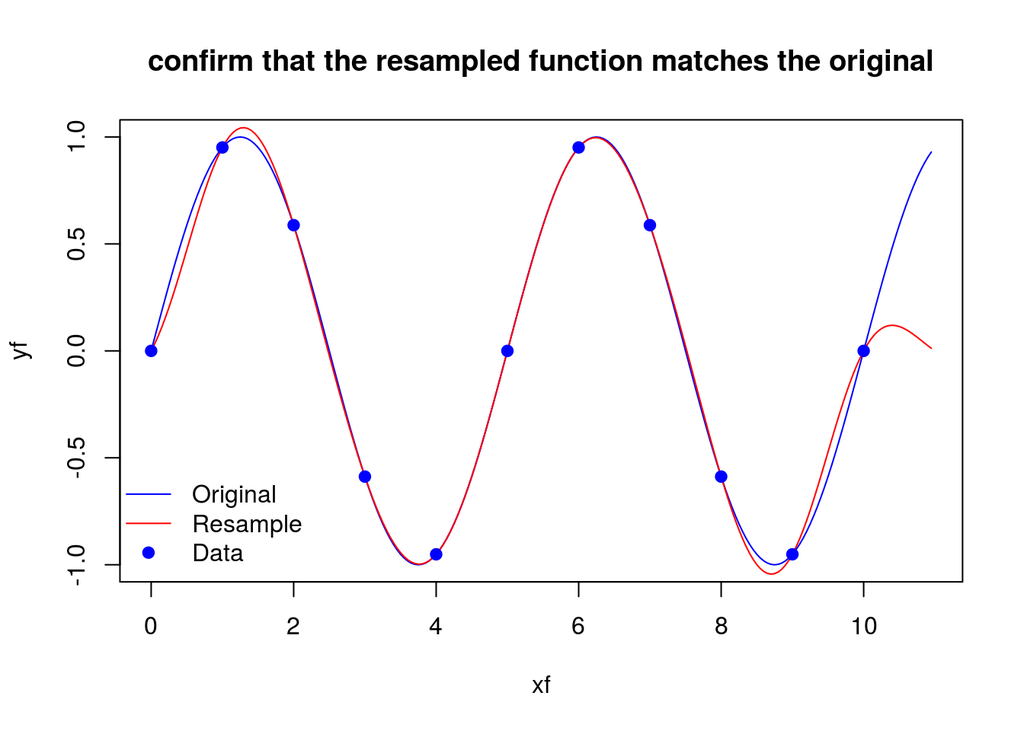

```r
xf <- seq(0, 10.95, by=0.05)
yf <- sin(2*pi*xf/5)
xp <- 0:10
yp <- sin(2*pi*xp/5)
r <- resample(yp, xp[2], xf[2])
plot(xf, yf, type = "l", col = "blue")
title("confirm that the resampled function matches the original")
lines(xf, r[1:length(xf)], col = "red")
points(xp,yp, pch = 19, col = "blue")
legend("bottomleft", c("Original", "Resample", "Data"), col = c("blue", "red", "blue"), pch = c(NA, NA, 19), lty = c(1, 1, NA), bty = "n")
```

## `roots` : Roots of a polynomial

```r
roots(1:3)
```

```
## [1] -1+1.414214i -1-1.414214i
```

```r
polyroot(3:1) # should be the same
```

```
## [1] -1+1.414214i -1-1.414214i
```

```r
poly(roots(1:3))
```

```
## [1] 1+0i 2+0i 3+0i
```

## `sftrans` : Transform filter band edges

Transform band edges of a generic lowpass filter to a filter with different band edges and to other filter types (high pass, band pass, or band stop).

## `sgolay` : Savitzky-Golay smoothing filters

Computes the filter coefficients for all Savitzky-Golay smoothing filters.

## `sgolayfilt` : Apply a Savitzky-Golay smoothing filter

Smooth data with a Savitzky-Golay smoothing filter. These filters are particularly good at preserving lineshape while removing high frequency squiggles.

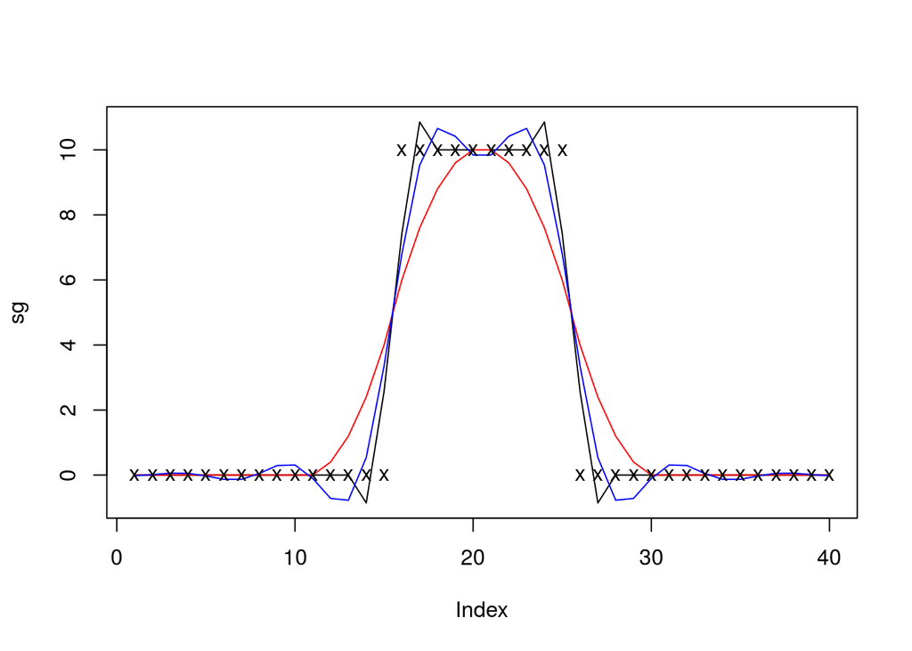

```r
# Compare a 5 sample averager, an order-5 butterworth lowpass
# filter (cutoff 1/3) and sgolayfilt(x, 3, 5), the best cubic
# estimated from 5 points.
bf <- butter(5,1/3)
x <- c(rep(0,15), rep(10, 10), rep(0, 15))
sg <- sgolayfilt(x)
plot(sg, type="l")
lines(filtfilt(rep(1, 5)/5,1,x), col = "red") # averaging filter
lines(filtfilt(bf,x), col = "blue") # butterworth
points(x, pch = "x") # original data
```

## `signal-internal` : Internal or uncommented functions

## `specgram` : Spectrogram plot

Generate a spectrogram for the signal. This chops the signal into overlapping slices, windows each slice and applies a Fourier transform to determine the frequency components at that slice.

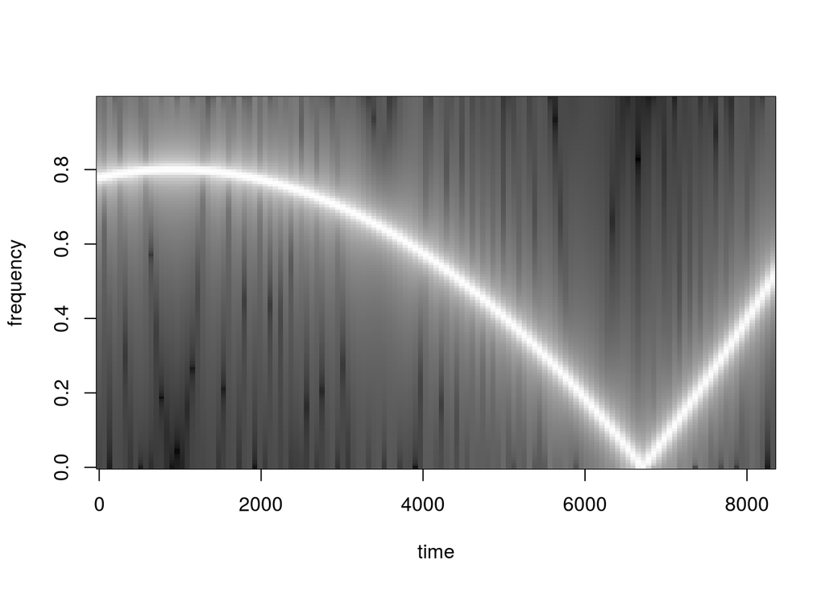

```r
specgram(chirp(seq(-2, 15, by = 0.001), 400, 10, 100, 'quadratic'))
```

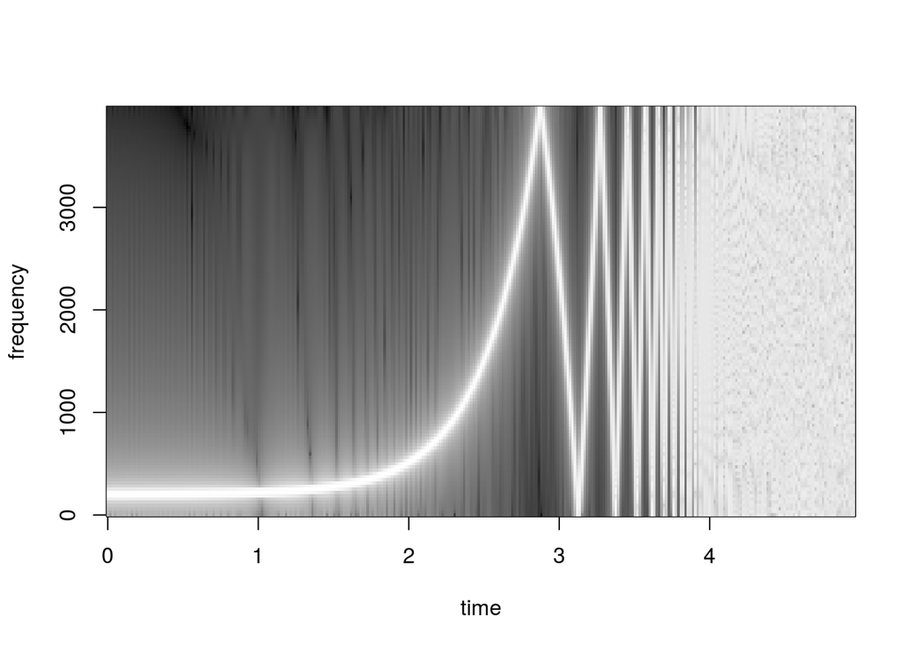

```r
specgram(chirp(seq(0, 5, by = 1/8000), 200, 2, 500, "logarithmic"), Fs = 8000)
```

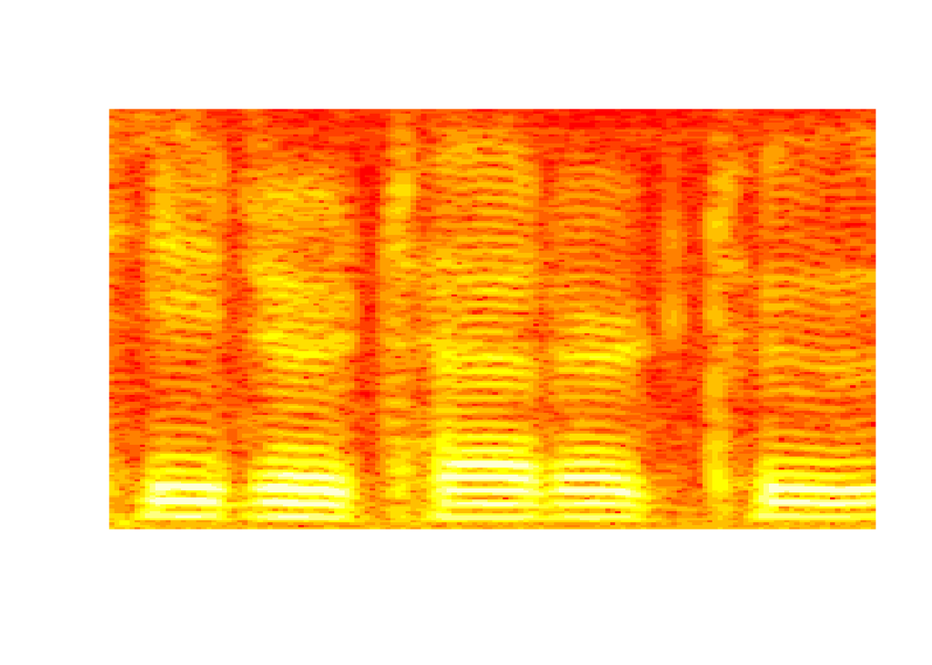

```r
data(wav) # contains wav$rate, wav$sound
Fs <- wav$rate
step <- trunc(5*Fs/1000) # one spectral slice every 5 ms
window <- trunc(40*Fs/1000) # 40 ms data window
fftn <- 2^ceiling(log2(abs(window))) # next highest power of 2
spg <- specgram(wav$sound, fftn, Fs, window, window-step)
S <- abs(spg$S[2:(fftn*4000/Fs),]) # magnitude in range 0<f<=4000 Hz.
S <- S/max(S) # normalize magnitude so that max is 0 dB.
S[S < 10^(-40/10)] <- 10^(-40/10) # clip below -40 dB.
S[S > 10^(-3/10)] <- 10^(-3/10) # clip above -3 dB.
image(t(20*log10(S)), axes = FALSE) #, col = gray(0:255 / 255))
```

## `spencer` : Spencer filter

Spencer’s 15-point moving average filter.

## `unwrap` : Unwrap radian phases

Unwrap radian phases by adding multiples of 2*pi as appropriate to remove jumps.

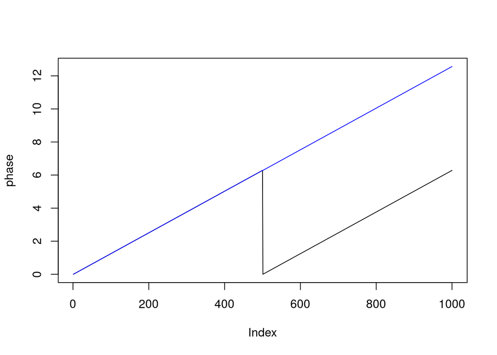

```r
phase <- c(seq(0, 2*pi, length=500), seq(0, 2*pi, length=500))
plot(phase, type = "l", ylim = c(0, 4*pi))
lines(unwrap(phase), col = "blue")
```

## `wav` : Example wav file

Example .wav file audio waveshape from Octave.

```r
data(wav)
str(wav)
```

```
## List of 3
##  $ sound: num [1, 1:17380] -0.000275 -0.00061 -0.000397 -0.000793 -0.000305 ...
##  $ rate : int 22050
##  $ bits : int 16
##  - attr(*, "class")= chr "Sample"
```

## `Windowing functions`

A variety of generally Matlab/Octave compatible filter generation functions, including Bartlett, Blackman, Hamming, Hanning, and triangular.

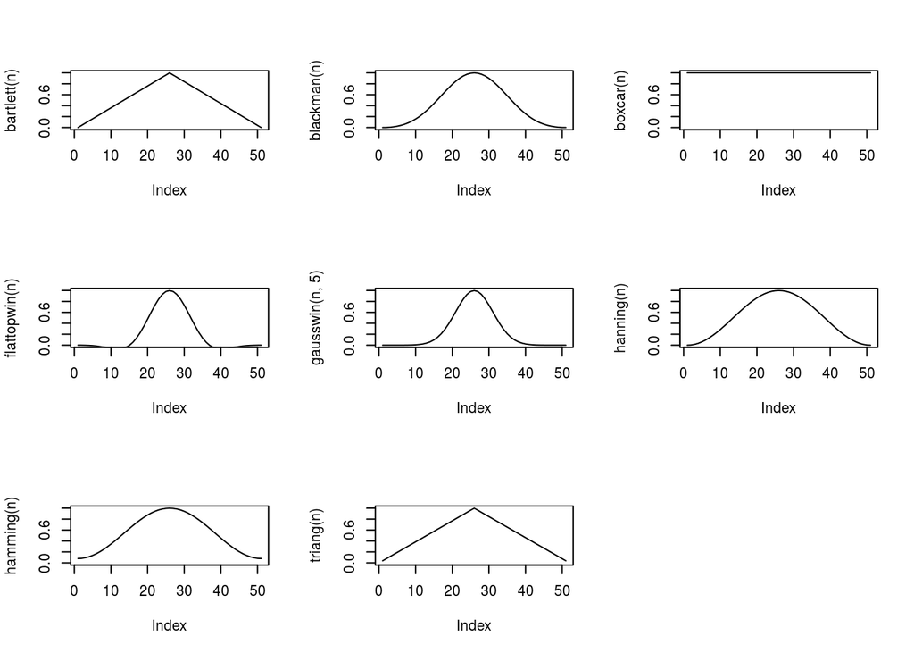

```r
n <- 51
op <- par(mfrow = c(3,3))
plot(bartlett(n), type = "l", ylim = c(0,1))
plot(blackman(n), type = "l", ylim = c(0,1))
plot(boxcar(n), type = "l", ylim = c(0,1))
plot(flattopwin(n), type = "l", ylim = c(0,1))
plot(gausswin(n, 5), type = "l", ylim = c(0,1))
plot(hanning(n), type = "l", ylim = c(0,1))
plot(hamming(n), type = "l", ylim = c(0,1))
plot(triang(n), type = "l", ylim = c(0,1))
par(op)
```

## `Zpg` : Zero-pole-gain model

Zero-pole-gain model of an ARMA filter.

## `zplane` : Pole-zero plot

Plot the poles and zeros of a model or filter.

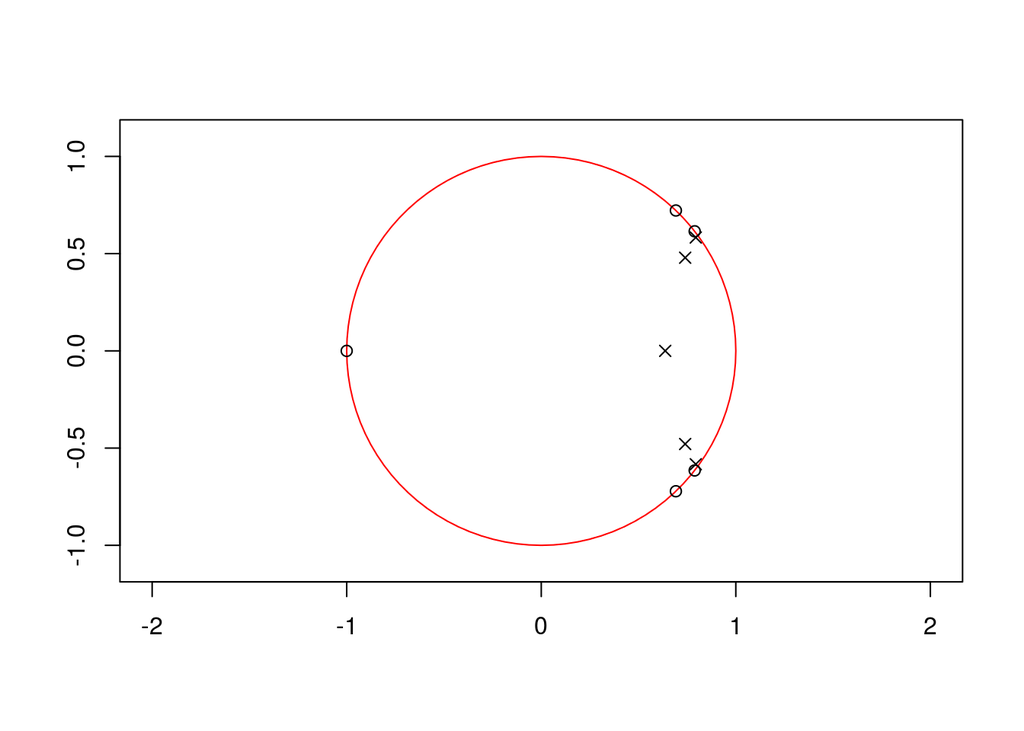

```r
filt <- ellip(5, 0.5, 20, .2)
zplane(filt)
```

© MIT License, 2017 - [Paige Bailey](http://www.dynamicwebpaige.com)